# Exploration Well Fluid Property - Data Analytic Perspective

Tien Phan

October 3, 2018

## 1. Data Loading, Descriptive Statistic

```r
fluiddata = read.csv('../data/FluidData.csv')
labdata = read.csv('../data/LabData.csv')

#str(fluiddata)
```

This page uses fluiddata frame which is resulted from lab, well-test and mudlog corrected (MLC) combination. Labdata only will be investigated separatedly at a later time.

First, let’s get the descriptive statistics for entire data set:

```
##        Id        Block    Area        WellName         X
##  Min.   :  1.0   52:185   AQ:116   AQ-5X  : 26   Min.   :234042
##  1st Qu.: 66.5   B : 78   CV: 69   CV-3X  : 24   1st Qu.:241493
##  Median :132.0            KL: 57   KL-4X  : 22   Median :255329
##  Mean   :132.0            TH: 13   AQ-1X  : 21   Mean   :251749
##  3rd Qu.:197.5            VD:  8   KL-3X  : 19   3rd Qu.:256260
##  Max.   :263.0                     CV-1X  : 17   Max.   :269406
##                                    (Other):134
##        Y          Horizon    SandName      TopSand          BaseSand
##  Min.   :886833   F:101   F_60   :  4   Min.   :-10068   Min.   :-10084
##  1st Qu.:917319   H: 75   F_78   :  4   1st Qu.: -7826   1st Qu.: -7837
##  Median :926935   I: 54   F_94   :  4   Median : -6541   Median : -6546
##  Mean   :926573   J: 18   F_24   :  3   Mean   : -6719   Mean   : -6528
##  3rd Qu.:933878   M: 15   F_27   :  3   3rd Qu.: -5620   3rd Qu.: -5578
##  Max.   :969726           F_58   :  3   Max.   : -3818   Max.   :     0
##                           (Other):242
##  DataSource DataSourceMDT     Netpay         Porosity           Sw
##  MDT: 65    MLC    :173   Min.   : 0.70   Min.   :10.90   Min.   :11.00
##  MLC:173    MDT    : 19   1st Qu.: 3.30   1st Qu.:14.95   1st Qu.:35.55
##  TST: 25    RDT    : 17   Median : 5.00   Median :17.90   Median :46.00
##             TST-3  :  6   Mean   :11.08   Mean   :18.51   Mean   :45.55
##             TST-1  :  5   3rd Qu.:11.65   3rd Qu.:21.45   3rd Qu.:56.70
##             TST-2  :  5   Max.   :91.50   Max.   :30.90   Max.   :68.10
##             (Other): 38
##       Egi              P              T               C1
##  Min.   : 96.4   Min.   :1698   Min.   : 88.0   Min.   :42.90
##  1st Qu.:137.8   1st Qu.:2536   1st Qu.:120.0   1st Qu.:69.75
##  Median :157.0   Median :3048   Median :137.6   Median :77.10
##  Mean   :158.9   Mean   :3184   Mean   :141.4   Mean   :77.16
##  3rd Qu.:180.7   3rd Qu.:3804   3rd Qu.:155.0   3rd Qu.:85.35
##  Max.   :227.8   Max.   :5345   Max.   :337.0   Max.   :94.80
##
##        C2               C3              iC4              nC4
##  Min.   : 0.300   Min.   : 0.000   Min.   :0.0000   Min.   :0.0000
##  1st Qu.: 2.400   1st Qu.: 0.400   1st Qu.:0.1000   1st Qu.:0.1000
##  Median : 3.600   Median : 2.100   Median :0.4000   Median :0.4000
##  Mean   : 3.965   Mean   : 2.521   Mean   :0.6863   Mean   :0.6384
##  3rd Qu.: 5.150   3rd Qu.: 4.150   3rd Qu.:1.2000   3rd Qu.:1.0000
##  Max.   :11.000   Max.   :10.200   Max.   :3.0000   Max.   :4.2000
##
```

[output cut: 9 more lines]

```
##  Min.   :0.000000   Min.   : 0.00   Min.   : 0.500   Min.   : 99.57
##  1st Qu.:0.000000   1st Qu.: 4.20   1st Qu.: 1.900   1st Qu.:100.00
##  Median :0.000000   Median : 8.20   Median : 2.800   Median :100.00
##  Mean   :0.004918   Mean   :11.16   Mean   : 3.382   Mean   :100.00
##  3rd Qu.:0.000000   3rd Qu.:14.65   3rd Qu.: 4.600   3rd Qu.:100.00
##  Max.   :0.200000   Max.   :52.10   Max.   :13.300   Max.   :100.20
##  NA's   :19
##       GHV
##  Min.   : 450.0
##  1st Qu.: 926.0
##  Median :1004.0
##  Mean   : 976.4
##  3rd Qu.:1057.5
##  Max.   :1288.0
##
```

## 2. Visualization, Outliers and Missing Values

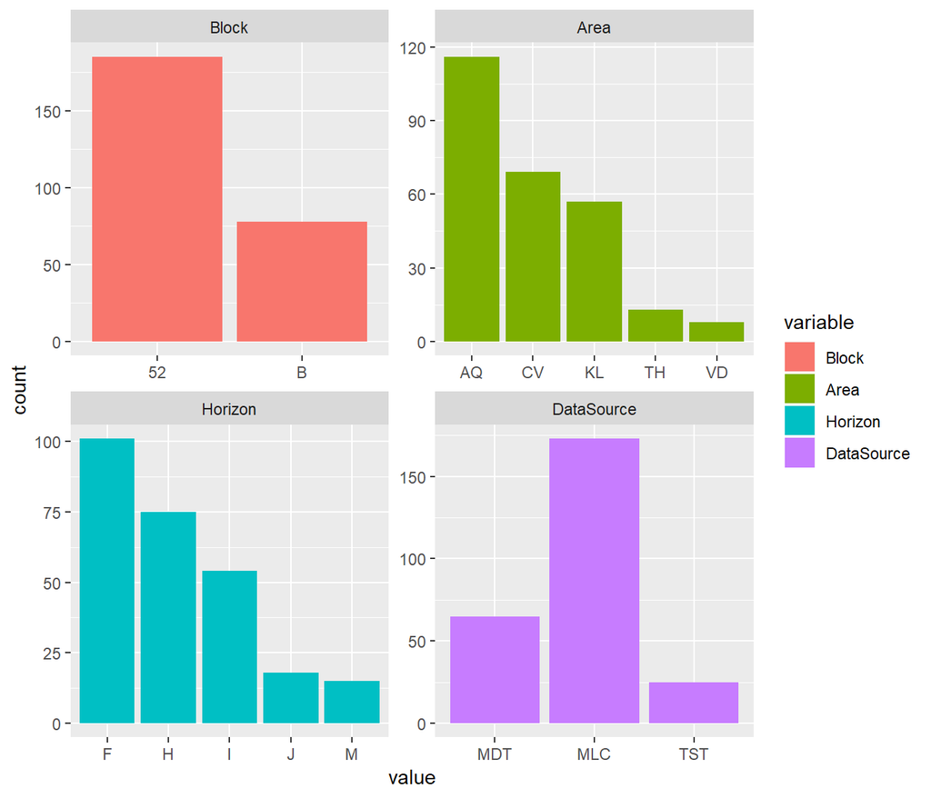

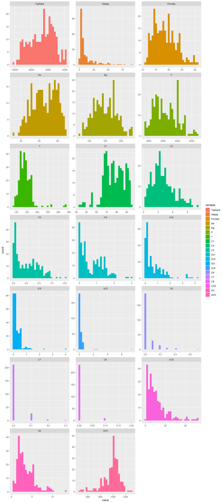

Observation:

### Outliers

Now, look at the boxplot of the key features which seems to have outliers identified from previous histogram:

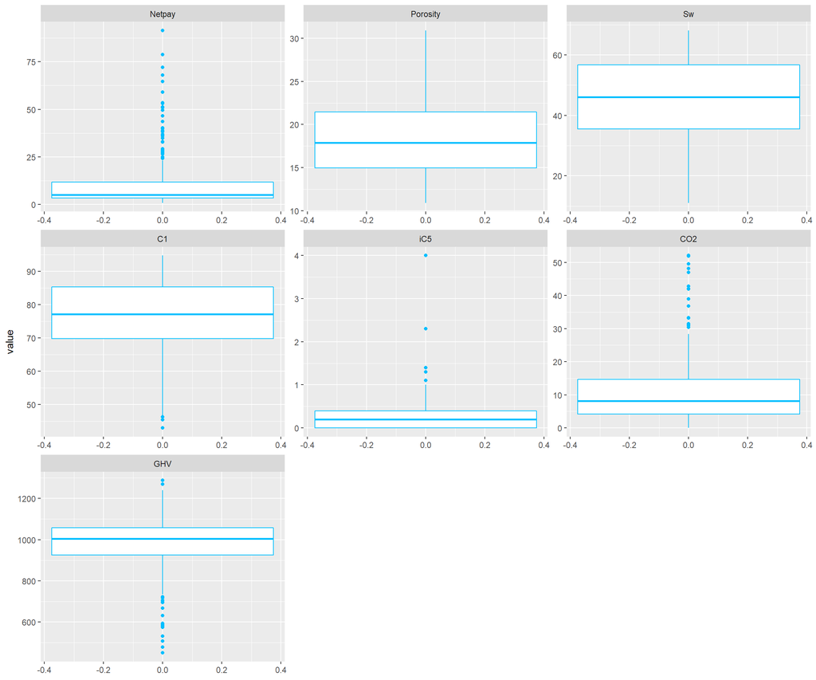

- Porosity, Sw and C1 seem to be normally distributed even though C1 has a some minor outliers at the low-end.
- Netpay, CO<sub>2</sub> and GHV have many outliers. In addition, iC5 has several outliers at the high-end. However, we ignore iC5 due to its narrow range and will focus on **Netpay** and **CO<sub>2</sub>** for further investigation. Most of the GHV data points in this study are formularized from C composition and CO<sub>2</sub> (i.e. MLC data source), so it correlates very well with CO<sub>2</sub> and compositions. Therefore, we ignore it in outlier analysis but it is considered as a dependent variable (response), so we will relate it in the model training and prediction at a later time.
- Facet with different categories as the following plots:

#### CO<sub>2</sub>:

- Once facetting in different horizons, CO<sub>2</sub> is more normally distributed. The high-end values (i.e. >30%) observed from the previous boxplot without facetting is now allocated to I and J horizons, mostly in AQ area.
- It turns out that the numbers of outliers of CO<sub>2</sub> are reduced to 5 (3 data points in AQ, 1 data point in each CV and KL: AQ-4X, AQ-7X, CV-3X and KL-3X).
- J Sand only appears in KL, AQ and CV areas and CO<sub>2</sub> in AQ is the highest. All CO<sub>2</sub> in J sand are relatively normal distribution.
- CO<sub>2</sub> of I formation in AQ area is variated significantly (i.e. from very low value less than 5% to the highest value of more than 50%). This distribution is far different with the remaining and it is very interested to investigate further.

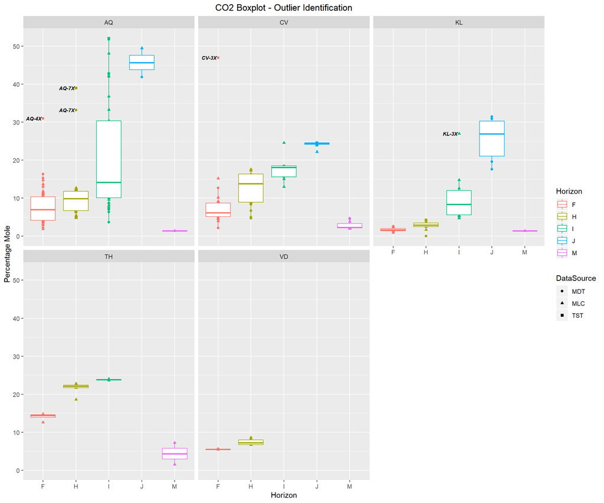

#### Netpay:

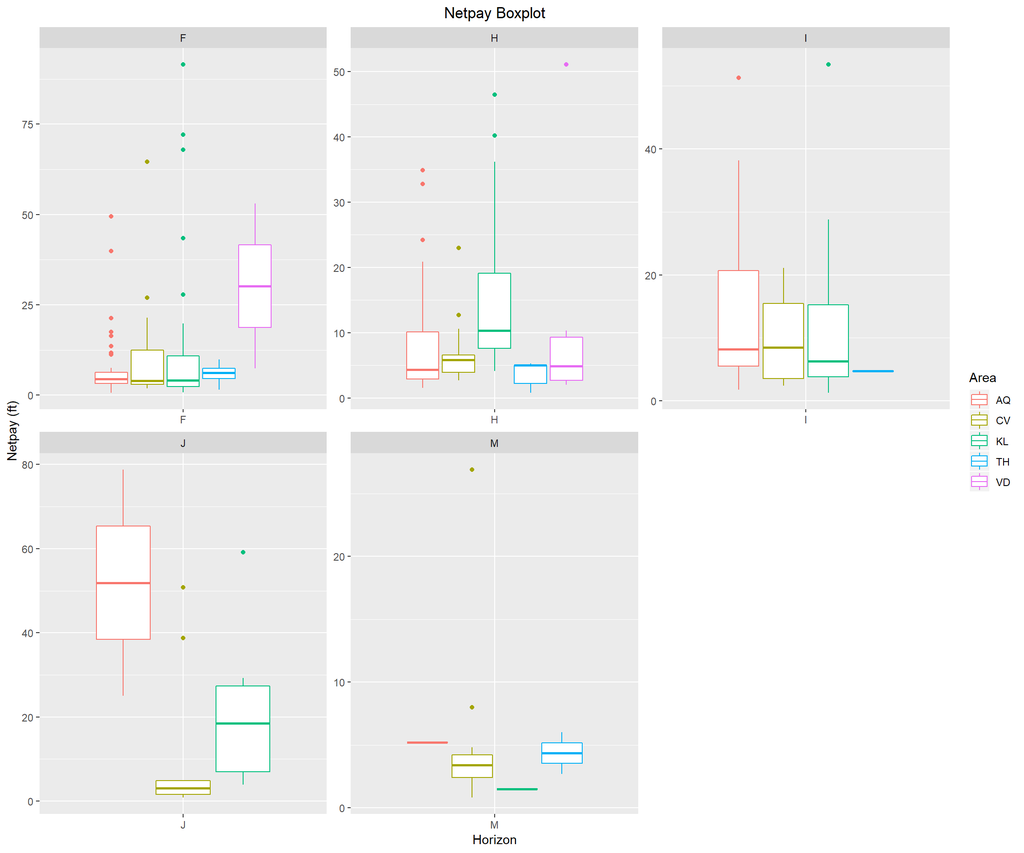

- We transform Netpay to log-normal as the following plot. It turns out that AQ and CV areas exist several outliers in the formation F, H, J and M as indicated in the wellname AQ4X, AQ6X, CV-1X, CV-4X and CV-5X.

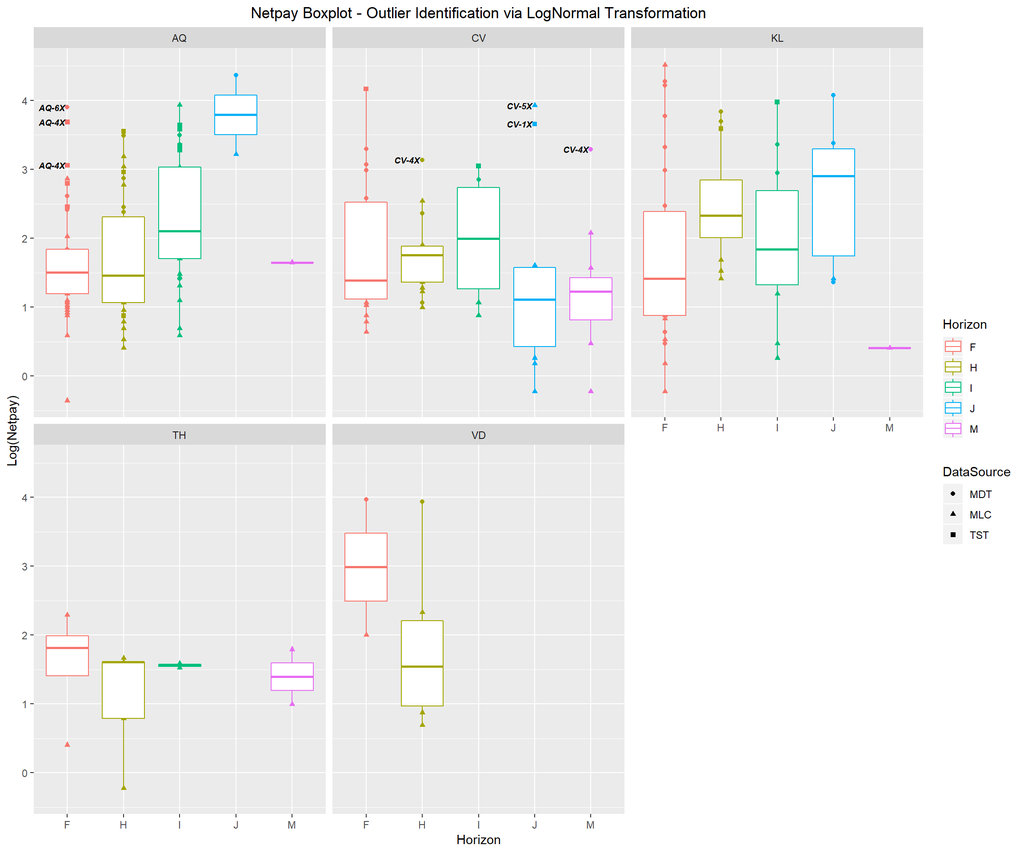

### Coming next: 3. Feature engineering, PCA and linear regression